# RepData_PeerAssessment1

```r
library(data.table)
library(ggplot2)
```

### 1. Code for reading in the dataset and/or processing the data

```r
data <- as.data.table(read.csv("activity.csv", header = TRUE, sep = ","))

# Add a column with the "date" column converted to a POSIXlt object
data[, pdate := as.POSIXct(date, tz = "", format = "%Y-%m-%d"), by = interval]
```

### 2. Histogram of the total number of steps taken each day

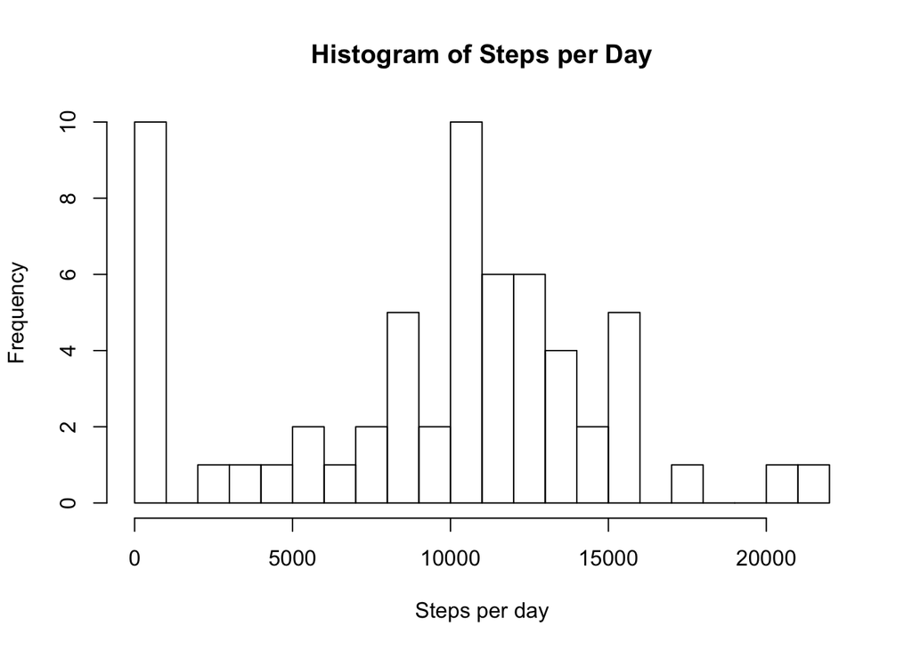

```r
steps_by_day <- copy(data[,c("steps", "date")])
setkey(steps_by_day, date)
steps_by_day_t <- steps_by_day[, .(total = sum(steps, na.rm = TRUE)), by = date]

hist(steps_by_day_t$total, xlab = "Steps per day", probability = FALSE, breaks = 20, main = "Histogram of Steps per Day")
```

### 3. Mean and median number of steps taken each day

Total number of steps taken per day:  
Mean : 9354.2295082  
Median: 10395

### 4. Time series plot of the average number of steps taken

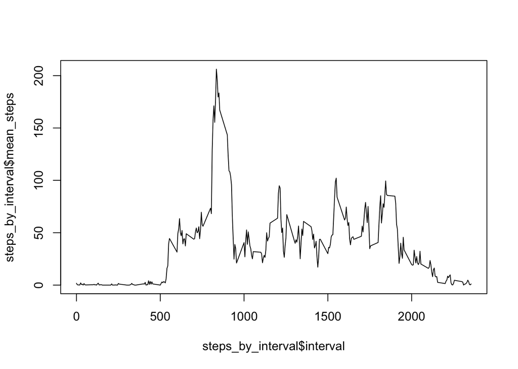

```r
steps_by_interval <- data[, .(mean_steps = mean(steps, na.rm = TRUE)), by = interval]
plot(steps_by_interval$interval, steps_by_interval$mean_steps, type="l")
```

### 5. The 5-minute interval that, on average, contains the maximum number of steps

```r
max_interval <- unique(steps_by_interval[mean_steps==max(steps_by_interval$mean_steps)]$interval)
```

[output not shown]

### 6. Code to describe and show a strategy for imputing missing data

For value where steps is NA, set it to the mean for that 5-minute interval.

#### What is the impact of imputing missing data on the estimates of the total daily number of steps?

The estimates go up, since unreported intervals now have positive number of steps

### 7. Histogram of the total number of steps taken each day after missing values are imputed

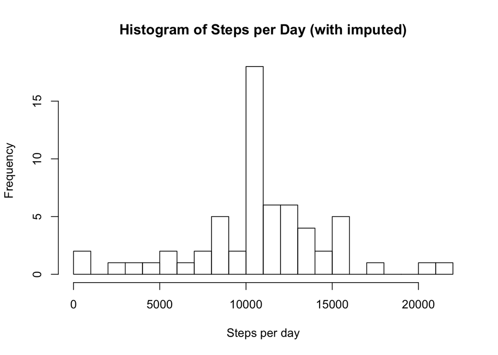

```r
imputed_data <- copy(data)
# imputed_data[, meand := get_mean_for_day(date)]


i_steps_by_interval <- NULL

get_mean_for_interval <- function(interval) {
    i_steps_by_interval[i_steps_by_interval$interval == interval]$mean_steps
}

i_steps_by_interval <- imputed_data[, .(mean_steps = mean(steps, na.rm = TRUE)), by = interval]

imputed_data[, meanv := get_mean_for_interval(interval)]

imputed_data$steps[is.na(imputed_data$steps)] <-
    imputed_data$meanv[is.na(imputed_data$steps)]

## Calculate mean & median for imputed values

i_steps_by_day <- copy(imputed_data[, c("steps", "date")])
setkey(i_steps_by_day, date)
i_steps_by_day_t <-
    i_steps_by_day[, .(total = sum(steps)), by = date]

hist(
    i_steps_by_day_t$total,
    xlab = "Steps per day",
    probability = FALSE,
    breaks = 20,
    main = "Histogram of Steps per Day (with imputed)"
)
```

### 8. Panel plot comparing the average number of steps taken per 5-minute interval across weekdays and weekends

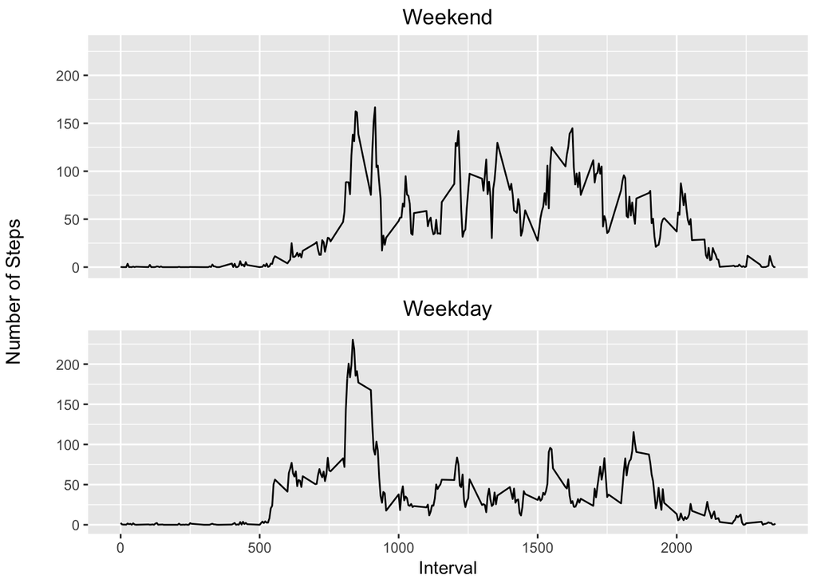

```r
is_weekend_day <- function(xdatetime) {
    as.factor(weekdays(xdatetime)) %in% c("Saturday", "Sunday")
}

imputed_data[, weekend := is_weekend_day(pdate)]

steps_by_interval_weekend <- imputed_data[imputed_data$weekend, .(mean_steps = mean(steps, na.rm = TRUE)), by = interval]
steps_by_interval_weekday <- imputed_data[!imputed_data$weekend, .(mean_steps = mean(steps, na.rm = TRUE)), by = interval]

library(magrittr)
library(ggpubr)

## scale_y_continuous(position = "right") +

max_y_value <- max(max(steps_by_interval_weekend$mean_steps), max(steps_by_interval_weekday$mean_steps))

weekend_plot <-
    ggplot(steps_by_interval_weekend, aes(interval, mean_steps)) + geom_line() +
    xlab("") + ylab("") + ggtitle("Weekend") +
    coord_cartesian(ylim = c(0, max_y_value)) +
    theme(axis.title.x=element_blank(),
          axis.text.x=element_blank(),
          axis.ticks.x=element_blank(),
          plot.title = element_text(hjust = 0.5))

weekday_plot <-
    ggplot(steps_by_interval_weekday, aes(interval, mean_steps)) + geom_line() +
    xlab("Interval") + ylab("") + ggtitle("Weekday") +
    coord_cartesian(ylim = c(0, max_y_value)) +
    theme(plot.title = element_text(hjust = 0.5))

panel_plot <- ggarrange(weekend_plot, weekday_plot, ncol = 1, nrow = 2)
panel_plot <- annotate_figure(panel_plot,
                left = text_grob("Number of Steps", color = "black", rot = 90)
)
show(panel_plot)
```

There are a few quick observations that can be made from the panel plot:

- The person is active earlier in the morning during the week
- The activity level is generally lower during the day on weekdays
- The maximum number is highest on a day during the week, not on the weekend